# Tugas_kelompok_uts_alel_1(4)

Anggota Kelompok :

1.Iman Yunar Noviadhi (2304130108)

2.Naufal Tipasha Denyana (2304130115)

3.Rizky Aulia Adi Saputro (2304130111)

4.Awan Saputra Romadhoni (2304130122)

```python
# import libraries for data manipulation
import numpy as np
import pandas as pd

# import libraries for data visualization
import matplotlib.pyplot as plt
import seaborn as sns

#Awan
```

```python
# read the data
df = pd.read_csv('foodhub_order.csv')
# returns the first 5 rows
df.head()

#Awan
```

|  | order_id | customer_id | restaurant_name | cuisine_type | cost_of_the_order | day_of_the_week | rating | food_preparation_time | delivery_time |
| --- | --- | --- | --- | --- | --- | --- | --- | --- | --- |
| 0 | 1477147 | 337525 | Hangawi | Korean | 30.75 | Weekend | Not given | 25 | 20 |
| 1 | 1477685 | 358141 | Blue Ribbon Sushi Izakaya | Japanese | 12.08 | Weekend | Not given | 25 | 23 |
| 2 | 1477070 | 66393 | Cafe Habana | Mexican | 12.23 | Weekday | 5 | 23 | 28 |
| 3 | 1477334 | 106968 | Blue Ribbon Fried Chicken | American | 29.20 | Weekend | 3 | 25 | 15 |
| 4 | 1478249 | 76942 | Dirty Bird to Go | American | 11.59 | Weekday | 4 | 25 | 24 |

```python
#Q1 (Awan)

#give number of rows and columns
num_rows, num_cols = df.shape

print("Number of rows: ", num_rows)
print("Number of columns: ", num_cols)
```

```
Number of rows:  1898
Number of columns:  9
```

Mencari tahu berapa banyak baris dan kolom dengan menggunakan syntax df.shape maka baris dan kolom akan terdisplay

```python
#Q2 (Awan)

#Data types of each columns
columns_data_type = df.dtypes

print("Data type: ")
print(columns_data_type)
```

```
Data type:
order_id                   int64
customer_id                int64
restaurant_name           object
cuisine_type              object
cost_of_the_order        float64
day_of_the_week           object
rating                    object
food_preparation_time      int64
delivery_time              int64
dtype: object
```

Mencari tahu tipe data perkolom menggunakan syntax "df.dtypes" untuk melakukan read pada dataset yang tersedia

```python
#Q3 (Awan)

missing_value = df.isnull().sum()

print("Missing value: ")
print(missing_value)
```

```
Missing value:
order_id                 0
customer_id              0
restaurant_name          0
cuisine_type             0
cost_of_the_order        0
day_of_the_week          0
rating                   0
food_preparation_time    0
delivery_time            0
dtype: int64
```

Mencari tahu apakah ada data yang hilang dengan menggunakan "df.isnull().sum()" untuk mencari tahu sejumlah data yang kosong dan menjumlahkannya per variabel

```python
#Q4 (Adi)

#Calculate statistical summary
min_prep_time = df['food_preparation_time'].min()
avg_prep_time = df['food_preparation_time'].mean()
max_prep_time = df['food_preparation_time'].max()

print("Minimum prep time:", min_prep_time)
print("Average prep time:", avg_prep_time)
print("Maximum prep time:", max_prep_time)
```

```
Minimum prep time: 20
Average prep time: 27.371970495258168
Maximum prep time: 35
```

**Mencari Food preparation tertinggi terendah dan rata rata** Dalam program tersebut menggunakan beberapa fungsi ada fungsi min untuk mengatur waktu terendah dalam waktu preparasi,max untuk waktu terlama dalam preparasi dan mean untuk rata rata preparasi makanan

```python
#Q5 (Adi)
#Not Given in Rating

# Count the number of orders where the rating is 'Not given'
num_not_rated = (df['rating'] == 'Not given').sum()

print("Number of orders not rated:", num_not_rated)
```

```
Number of orders not rated: 736
```

**Mencari berapa banyak orang yang tidak memberikan rating** Dalam program tersebut terdapat sum yang berarti menghitung berapa banyak Not given pada raing yang akan dijumlahkan untuk menemukan berapa orang yang tidak memberikan rating

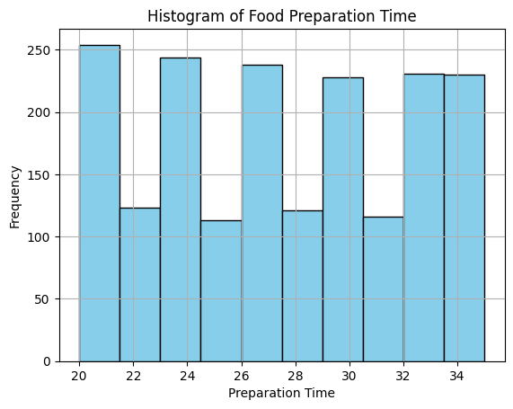

```python
#Q6 (Adi)
#Food Preparation

#Make an histrogram of food preparation with mathpolib fuction
plt.hist(df['food_preparation_time'], bins=10, color='skyblue', edgecolor='black')

plt.title('Histogram of Food Preparation Time')
plt.xlabel('Preparation Time')
plt.ylabel('Frequency')
plt.grid(True)

plt.show()
```

Dalam histrogram tersebut dapat diketahui bahwa peasanan dapat diproses atau disajikan dalam 20 menit sampai 34 menit lebih dengan waktu preparasi tercepat di 20 menit .Serta menjadi paling banyak yaitu diantara 20 dan kurang dari 22 dengan frekuensinya yaitu 250 an

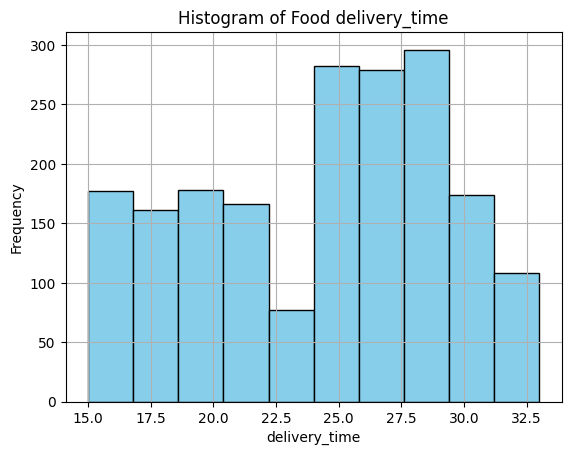

```python
#Delivery time (Adi)

#use df to read the data
plt.hist(df['delivery_time'], bins=10, color='skyblue', edgecolor='black')
#make title of histrogram and input data
plt.title('Histogram of Food delivery_time')
plt.xlabel('delivery_time')
plt.ylabel('Frequency')
plt.grid(True)

plt.show()
```

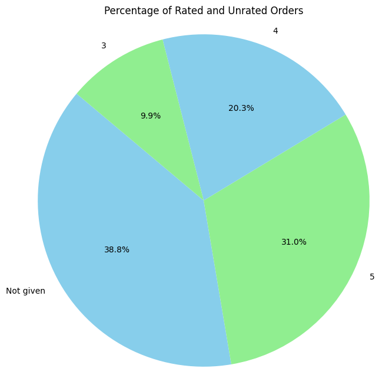

```python
# Assuming 'rating' is the column indicating whether an order is rated or not (Adi)
# Count the occurrences of each rating status
rating_counts = df['rating'].value_counts()

# Plotting the pie chart
plt.figure(figsize=(8, 8))
plt.pie(rating_counts, labels=rating_counts.index, autopct='%1.1f%%', startangle=140, colors=['skyblue', 'lightgreen'])
plt.title('Percentage of Rated and Unrated Orders')
plt.axis('equal')  # Equal aspect ratio ensures that pie is drawn as a circle.
plt.show()
```

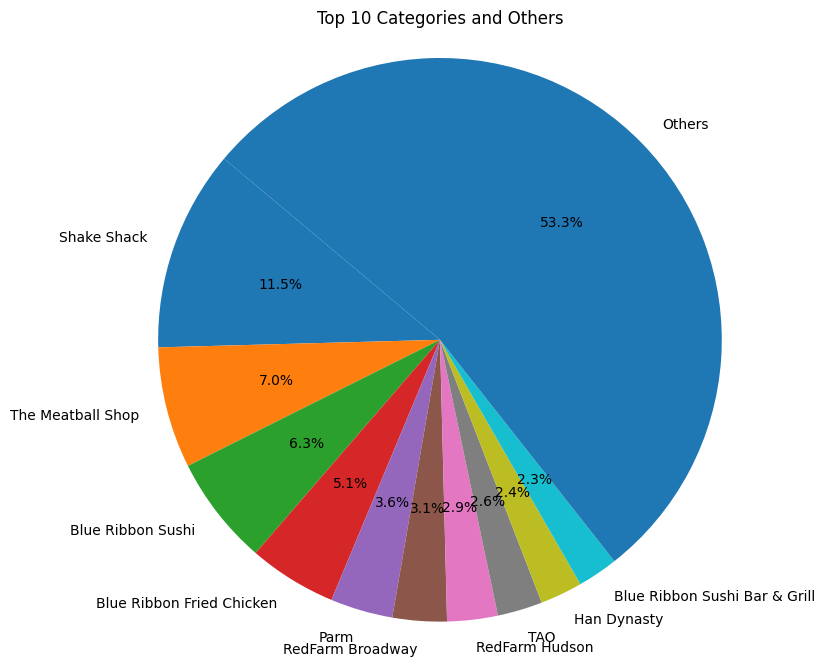

```python
# Assuming 'restaurant_name' is the column containing the categories you want to analyze (Adi)
# Count the occurrences of each restaurant_name
restaurant_name_counts = df['restaurant_name'].value_counts()

# Get the top 10 categories
top_10_categories = restaurant_name_counts.head(10)

# Sum up the counts of the remaining categories
others_count = restaurant_name_counts[10:].sum()

# Combine the top 10 categories and 'others'
final_restaurant_name_counts = top_10_categories.append(pd.Series({'Others': others_count}))

# Plotting the pie chart
plt.figure(figsize=(8, 8))
plt.pie(final_restaurant_name_counts, labels=final_restaurant_name_counts.index, autopct='%1.1f%%', startangle=140)
plt.title('Top 10 Categories and Others')
plt.axis('equal')  # Equal aspect ratio ensures that pie is drawn as a circle.
plt.show()
```

dikarena banyaknya Nama restauran dalam data tersebut jadi dalam diagram lingkaran ini saya buat menjadai sepuluh restauran teratas dan juga beberapa makanan dengan presentasi sedikit saya buat menjadi other agar digram tidak error.dengan data tersebut dapat kita simpulkan bahwa kebanyakan pembeli membeli di restauran shake shack dalam data tersebut.diperingkat dua ada the meatball shop dan ketiga ada Blue ribbon sushi.

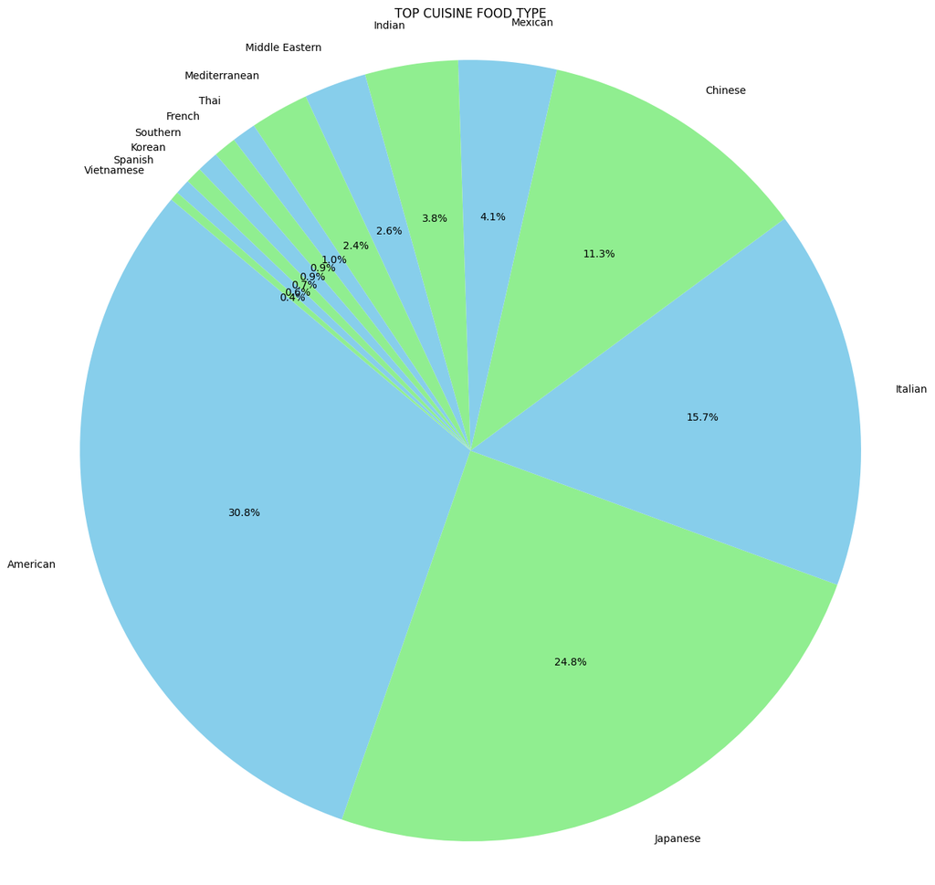

```python
# Assuming 'cuisine_type' is the column indicating whether an order is rated or not (Adi)
# Count the occurrences of each cuisine_type status
cuisine_type_counts = df['cuisine_type'].value_counts()

# Plotting the pie chart
plt.figure(figsize=(15, 15))
plt.pie(cuisine_type_counts, labels=cuisine_type_counts.index, autopct='%1.1f%%', startangle=140, colors=['skyblue', 'lightgreen'])
plt.title('TOP CUISINE FOOD TYPE')
plt.axis('equal')  # Equal aspect ratio ensures that pie is drawn as a circle.
plt.show()
```

Dalam diagram lingkaran tersebut dapat diketahui bahwa kebanyakan pembeli menyukai makanan amerika dengan 30,8% .Yang kedua ada makanan jepang dengan presentasi 24,8% makanan italia 15,7 % dan adajuga yang lainnya

[figure not shown]

```python
#day_of_the_week (Adi)
# Assuming 'day_of_the_week' is the column indicating whether an order is rated or not
# Count the occurrences of each day_of_the_week status
day_of_the_week_counts = df['day_of_the_week'].value_counts()

# Plotting the pie chart
plt.figure(figsize=(8, 8))
plt.pie(day_of_the_week_counts, labels=day_of_the_week_counts.index, autopct='%1.1f%%', startangle=140, colors=['skyblue', 'lightgreen'])
plt.title('Percentage of Rated and Unrated Orders')
plt.axis('equal')  # Equal aspect ratio ensures that pie is drawn as a circle.
plt.show()
```

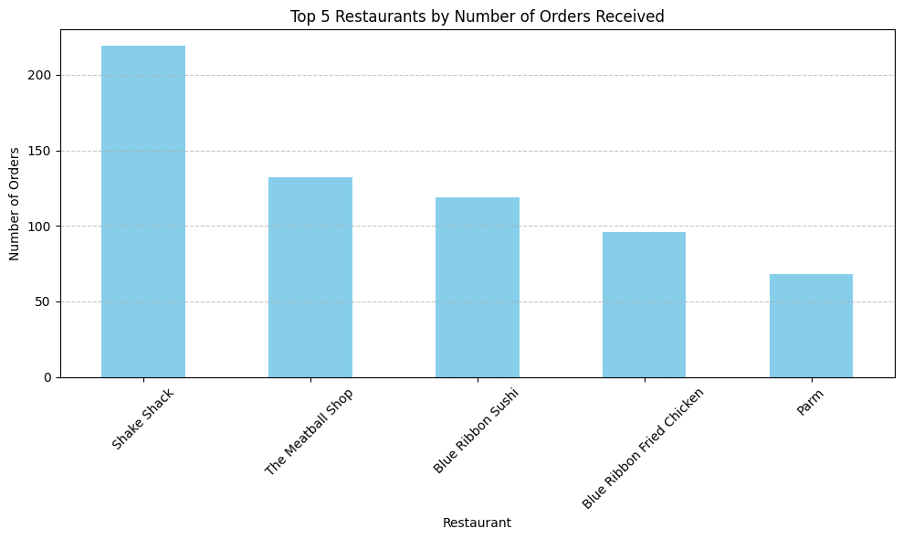

```python
#Q7 (Iman)
top_5_restaurants = df['restaurant_name'].value_counts().nlargest(5)
plt.figure(figsize=(10, 6))
top_5_restaurants.plot(kind='bar', color='skyblue')
plt.title('Top 5 Restaurants by Number of Orders Received')
plt.xlabel('Restaurant')
plt.ylabel('Number of Orders')
plt.xticks(rotation=45)
plt.grid(axis='y', linestyle='--', alpha=0.7)
plt.tight_layout()
plt.show()
```

top_5_restaurants = df['restaurant_name'].value_counts().nlargest(5): Baris ini menghitung jumlah pesanan yang diterima setiap restoran di df DataFrame dan menggunakan metode nlargest(5) untuk menemukan lima restoran teratas.Hasilnya disimpan dalam variabel top_5_restaurants.

plt.figure(figsize=(10, 6)): Membuat objek Gambar berukuran 10" x 6" menggunakan plt.figure() dari matplotlib.pyplot (biasa disingkat plt).

top_5_restaurants.plot(kind='bar', color='skyblue'): Membuat plot batang dari data top_5_restaurants menggunakan metode Lot() Pandas DataFrame. Parameter kind='bar' menentukan jenis grafik yang akan digunakan (dalam hal ini grafik batang), dan color='skyblue' menentukan warna batang.

plt.xlabel('Restaurant'): Gunakan plt.xlabel() untuk memberi label pada sumbu X (horizontal) dengan teks 'Restaurant'.

plt.xticks(rotation=45): Gunakan plt.xticks() untuk memutar label pada sumbu x sebesar 45 derajat agar label panjang lebih mudah dibaca.

plt.grid(axis='y', linestyle='--', alpha=0.7): Baris ini menambahkan garis grid sepanjang sumbu y dengan gaya putus-putus dan mengatur tingkat transparansi menjadi 0.7.

plt.tight_layout(): Gunakan plt.tight_layout() untuk menyesuaikan tata letak plot agar terlihat lebih rapi.Ini membantu menghindari duplikasi antar elemen plot.

plt.show(): Menampilkan bagan yang dibuat dengan plt.show().Ini mencetak representasi ke layar untuk dilihat pengguna.

```
The most popular cuisine on weekends is: American
```

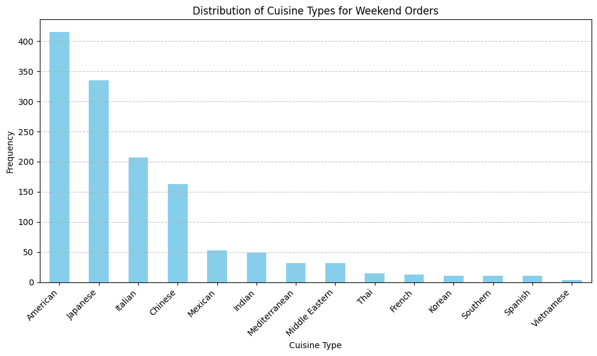

```python
#Q8 (Iman)
weekend_orders = df[df['day_of_the_week'].isin(['Weekend'])]
most_popular_cuisine_weekends = weekend_orders['cuisine_type'].value_counts().idxmax()
print("The most popular cuisine on weekends is:", most_popular_cuisine_weekends)
plt.figure(figsize=(10, 6))
weekend_orders['cuisine_type'].value_counts().plot(kind='bar', color='skyblue')
plt.title('Distribution of Cuisine Types for Weekend Orders')
plt.xlabel('Cuisine Type')
plt.ylabel('Frequency')
plt.xticks(rotation=45, ha='right')
plt.grid(axis='y', linestyle='--', alpha=0.7)
plt.tight_layout()
plt.show()
```

plt.figure(figsize=(10, 6)): Ini menciptakan gambar dengan lebar 10 inci dan tinggi 6 inci.

Weekend_orders['cuisine_type'].value_counts().plot(kind='bar', color='skyblue'): Ini membuat grafik batang jumlah kemunculan setiap jenis masakan di bingkai data Weekend_orders.

plt.xlabel('Cuisine Type'): Ini menambahkan label ke sumbu x.

plt.ylabel('Frequency'): Ini menambahkan label ke sumbu y.

plt.xticks(rotation=45, ha='right'): Ini memutar label sumbu x sebesar 45 derajat dan menempatkannya di sisi kanan agar lebih mudah dibaca. plt.grid(axis='y', linestyle='--', alpha=0.7): Ini menambahkan grid ke sumbu y dengan gaya garis putus-putus dan tingkat transparansi 0,7.

plt.tight_layout(): Ini menyesuaikan tata letak plot. plt.show(): Ini menampilkan plot yang dihasilkan.

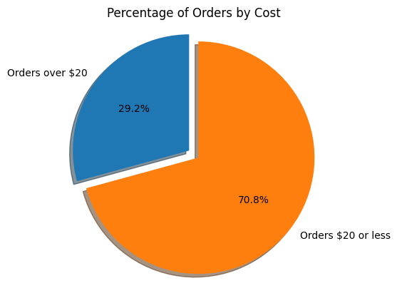

```python
#Q9 (Iman)
orders_over_20 = df[df['cost_of_the_order'] > 20]
percentage_over_20 = (len(orders_over_20) / len(df)) * 100
percentage_below_20 = 100 - percentage_over_20
labels = 'Orders over $20', 'Orders $20 or less'
sizes = [percentage_over_20, percentage_below_20]
explode = (0.1, 0)

fig1, ax1 = plt.subplots()
ax1.pie(sizes, explode=explode, labels=labels, autopct='%1.1f%%',
        shadow=True, startangle=90)
ax1.axis('equal')

plt.title('Percentage of Orders by Cost')
plt.show()
```

df['cost_of_the_order'] > 20: Ini adalah kondisi yang memeriksa apakah nilai di kolom 'cost_of_the_order' lebih besar dari $20.

df[df['cost_of_the_order'] > 20: Ini adalah cara memfilter kerangka data df berdasarkan suatu kondisi dan mendapatkan baris yang hanya berisi pesanan dengan biaya lebih besar dari $20.Data yang difilter disimpan di DataFrameorders_over_20.

len(orders_over_20): Ini menghitung jumlah baris di DataFrameorders_over_20, yaitu jumlah pesanan dengan biaya lebih dari $20. len(df): Ini menghitung jumlah baris dalam DataFrame df,yaitu total jumlah pesanan dalam dataset.

(len(orders_over_20) / len(df)) * 100: Ini menghitung persentase pesanan yang harganya lebih dari $20 dari total jumlah pesanan dan kemudian mengalikannya dengan 100 untuk mendapatkan persentasenya.

percentage_below_20 = 100 -percentage_over_20: Ini menghitung persentase pesanan dengan biaya $20 atau kurang dengan mengurangkan persentase pesanan dengan biaya lebih dari 20 dollar dari 100.

labels: Ini adalah label untuk setiap bagian diagram lingkaran. sizes: Ini adalah ukuran (dalam persentase) setiap bagian diagram lingkaran. explode: Ini adalah tupel yang menentukan seberapa jauh diagram lingkaran dari pusat.Dalam contoh ini, bagian pertama (pesanan di atas $20) memiliki jarak 0,1.

fig1, ax1 = plt.subplots(): Ini membuat subplot diagram lingkaran. ax1.pie(): Ini membuat diagram lingkaran dengan ukuran dan label yang telah ditentukan.autopct='%1.1f%%': Ini akan menambahkan persentase ke setiap bagian diagram lingkaran.Shadow=True: Ini menambahkan bayangan pada diagram lingkaran, menciptakan efek 3D.startangle=90: Ini menentukan sudut awal diagram lingkaran (mulai dari 90 derajat sesuai dengan posisi sumbu Y).

ax1.axis('equal'): Ini membuat diagram lingkaran terlihat seperti lingkaran, bukan elips, dengan memastikan sumbu x dan y berada pada skala yang sama.

```python
#Q10 (Iman)
mean_delivery_time = df['delivery_time'].mean()

print("Mean order delivery time:", mean_delivery_time)
```

```
Mean order delivery time: 24.161749209694417
```

df['delivery_time']: Ini mengakses kolom delivery_time dari df DataFrame, yang berisi waktu pengiriman untuk setiap pesanan.

.mean(): Metode yang menghitung rata-rata nilai di kolom delivery_time. mean_delivery_time: Rata-rata waktu pengiriman yang dihasilkan disimpan dalam variabel mean_delivery_time.

print("Mean order delivery time:", mean_delivery_time): Ini mencetak pesan yang berisi waktu pengiriman rata-rata untuk pesanan diikuti dengan nilai rata-rata yang disimpan dalam variabel mean_delivery_time.

```python
#Q11 (Iman)
customer_orders = df['customer_id'].value_counts()
top_3_customers = customer_orders.head(3)
print("Top 3 most frequent customers and their number of orders:")
print(top_3_customers)
```

```
Top 3 most frequent customers and their number of orders:
52832    13
47440    10
83287     9
Name: customer_id, dtype: int64
```

df['customer_id'].value_counts(): Ini menghitung jumlah pesanan setiap pelanggan dengan menghitung berapa kali setiap customer_id muncul di kolom ini.customer_orders: Hasil perhitungan disimpan pada variabel customer_orders yang berisi jumlah pesanan yang dilakukan oleh setiap pelanggan.

customer_orders.head(3): Ini mendapatkan 3 pelanggan teratas dengan pesanan terbanyak dari customer_orders. top_3_customers: Hasilnya disimpan dalam variabel top_3_customers. Variabel ini mencakup tiga pelanggan teratas dan jumlah pesanan setiap pelanggan.

Pesan "Top 3 most frequent customers and their number of orders:" dicetak pertama kali sebagai judul atau deskripsi.

print(top_3_customers): Ini mencetak tiga pelanggan teratas dan jumlah pesanan setiap pelanggan.

[figure not shown]

```python
#Q12 (Iman,Awan)

# Membuat heatmap untuk matriks korelasi antara variabel numerik dalam dataframe 'df'.
# Menetapkan ukuran gambar, memilih palet warna 'coolwarm', dan menampilkan nilai korelasi dengan 2 angka desimal.
plt.figure(figsize=(10, 8))
sns.heatmap(df.corr(), annot=True, cmap='coolwarm', fmt=".2f")
plt.title("Correlation Matrix of Numerical Variables")
plt.show()  # Menampilkan heatmap
```

df.corr() menghitung matriks korelasi dari DataFrame df yang berisi koefisien korelasi Pearson antara setiap pasangan variabel.

sns.heatmap() adalah fungsi yang mengambil matriks korelasi sebagai masukan dan membuat heatmap.

annot=True menunjukkan bahwa nilai korelasi harus ditampilkan di sel heatmap.

cmap='coolwarm' menunjukkan skema warna yang digunakan. Warna hangat (merah) menunjukkan korelasi positif, dan warna sejuk (biru) menunjukkan korelasi negatif.

fmt=".2f" menentukan format angka yang ditampilkan, dalam hal ini dua tempat desimal.

[output not shown]

[figure not shown]

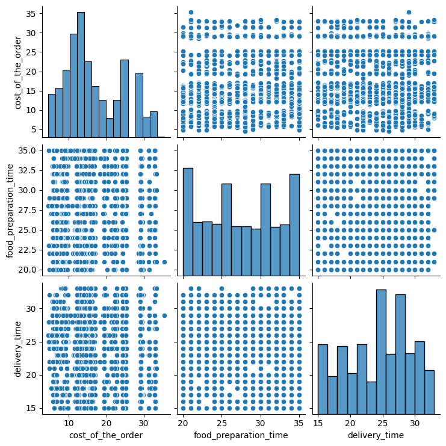

[figure not shown]

[figure not shown]

```python
#(Iman,Awan)
# Membuat pairplot untuk subset variabel numerik yang dipilih.
# Pairplot ini akan menampilkan hubungan pairwise antara 'cost_of_the_order', 'food_preparation_time', dan 'delivery_time'.
numerical_variables_subset = ['cost_of_the_order', 'food_preparation_time', 'delivery_time']
sns.pairplot(df[numerical_variables_subset])
plt.show()  # Menampilkan pairplot
```

numerical_variables_subset = ['cost_of_the_order', 'food_preparation_time', 'delivery_time'] Baris ini mendefinisikan sebuah list yang berisi nama-nama variabel numerik yang ingin visualisasikan.

Fungsi Seaborn yang disebut sns.pairplot() memungkinkan membuat grafik untuk setiap pasangan variabel dalam daftar yang berikan. df[numerical_variables_subset] mengambil subset dari DataFrame df, yang hanya mengandung kolom-kolom yang ditetapkan dalam numerical_variables_subset. Serangkaian plot akan dihasilkan oleh pairplot ini. Akan ada plot yang menunjukkan hubungan antara kedua variabel.

Untuk distribusi univariat masing-masing variabel, pairplot diagonal utama akan menampilkan histogram atau KDE (Kernel Density Estimate).

plt.show() baris terakhir ini akan menampilkan pairplot yang telah dibuat ke layar.

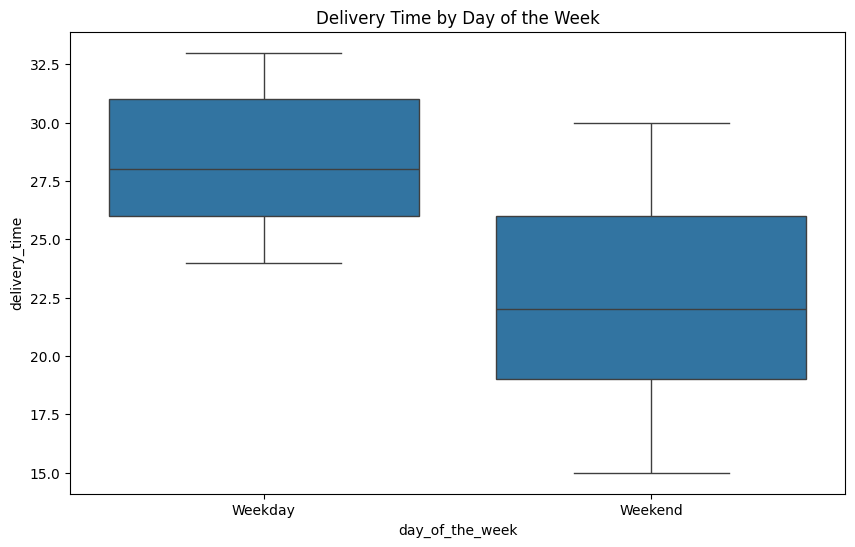

```python
#(Iman,Awan)
# Membuat boxplot untuk membandingkan 'delivery_time' antara hari dalam seminggu.
# Ini akan memberikan wawasan tentang bagaimana waktu pengiriman berbeda berdasarkan hari.
plt.figure(figsize=(10, 6))
sns.boxplot(x='day_of_the_week', y='delivery_time', data=df)
plt.title("Delivery Time by Day of the Week")
plt.show()  # Menampilkan boxplot
```

Fungsi sns.boxplot() dapat membuat boxplot. Pada sumbu x, variabel kategori adalah "hari dalam seminggu", dan pada sumbu y, variabel numerik adalah "waktu pengiriman". Data yang digunakan diambil dari DataFrame df, seperti yang ditunjukkan oleh data=df.

plt.title("Delivery Time by Day of the Week")menambahkan judul di atas boxplot.

Boxplot adalah alat yang bagus untuk menunjukkan distribusi data. Setiap "kotak" menampilkan kuartil pertama (Q1), median (Q2), dan ketiga (Q3).

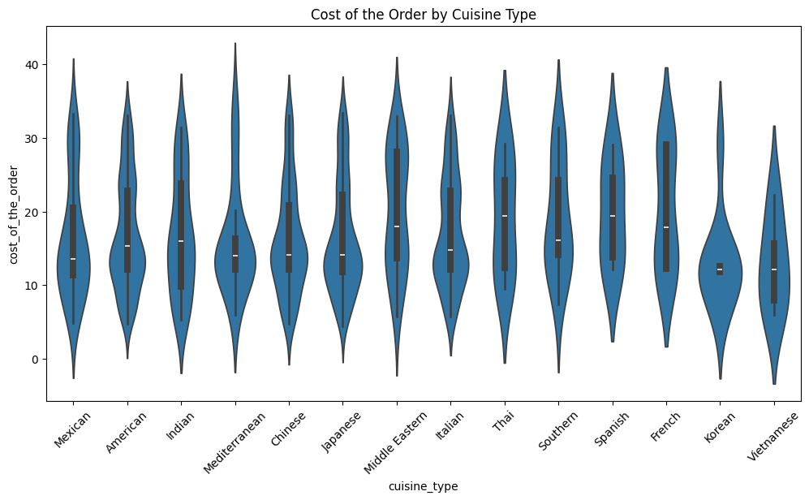

```python
#(Iman,Awan)
# Membuat violin plot untuk membandingkan 'cost_of_the_order' di antara berbagai jenis masakan.
# Violin plot memberikan gambaran tentang distribusi biaya pesanan dan kerapatan data.
plt.figure(figsize=(12, 6))
sns.violinplot(x='cuisine_type', y='cost_of_the_order', data=df)
plt.title("Cost of the Order by Cuisine Type")
plt.xticks(rotation=45)  # Memutar label sumbu x untuk memudahkan pembacaan
plt.show()  # Menampilkan violin plot
```

sns.violinplot() adalah fungsi yang membuat violin plot.

x='cuisine_type' menentukan variabel kategori pada sumbu x, yang dalam hal ini adalah jenis masakan.

y='cost_of_the_order' menentukan variabel numerik pada sumbu y, yang dalam hal ini adalah biaya pesanan.

data=df menunjukkan bahwa data yang digunakan berasal dari DataFrame df.

Untuk memvisualisasikan distribusi data numerik, violin plot adalah gabungan dari box plot dan kernel density plot, yang menunjukkan puncak dalam data. Berbeda dengan box plot, yang hanya dapat menampilkan statistik ringkasan, violin plot menampilkan kepadatan dan statistik ringkasan untuk setiap variabel123. Bagian violin plot yang lebih lebar menunjukkan kemungkinan yang lebih besar bahwa anggota populasi akan mengambil nilai tertentu, sedangkan bagian yang lebih kecil menunjukkan kemungkinan yang lebih rendah. Ini berguna untuk membandingkan distribusi biaya pesanan antara berbagai jenis masakan dan menemukan di mana distribusi biaya cenderung berkumpul atau menyebar.

```python
#Q13 (Naufal)

ratings = df.groupby('restaurant_name')['rating'].agg(['mean', 'count'])
eligible = ratings[(ratings['mean'] > 4) & (ratings['count'] > 50)]
print("Restaurants eligible for promotional offers:")
print(eligible)
```

```
Restaurants eligible for promotional offers:
                               mean  count
restaurant_name
Blue Ribbon Fried Chicken  4.328125     64
Blue Ribbon Sushi          4.219178     73
Shake Shack                4.278195    133
The Meatball Shop          4.511905     84
```

codingan tersebut menghitung rata-rata rating dan jumlah rating untuk setiap restoran, lalu memilih restoran-restoran yang memenuhi syarat untuk penawaran promosi berdasarkan kriteria tertentu, dan mencetak daftar restoran yang memenuhi syarat tersebut.

```python
#Q14 (Naufal)
def revenue(row):
    if row['cost_of_the_order'] > 20:
        return row['cost_of_the_order'] * 0.25
    elif row['cost_of_the_order'] > 5:
        return row['cost_of_the_order'] * 0.15
    else:
        return 0

df['revenue'] = df.apply(revenue, axis=1)
print(f"Net revenue: ${df['revenue'].sum():.2f}")
```

```
Net revenue: $3865.57
```

Ini digunakan untuk menghitung penjualan bersih berdasarkan biaya pesanan dengan menerapkan fungsi penjualan ke setiap baris df DataFrame dan mengeluarkan jumlah penjualan bersih untuk semua pesanan.

```python
#Q15 (Naufal)
mean_weekday_delivery = df[df['day_of_the_week'] == 'Weekday']['delivery_time'].mean()
mean_weekend_delivery = df[df['day_of_the_week'] == 'Weekend']['delivery_time'].mean()

print(f"Mean delivery time on weekdays: {mean_weekday_delivery:.2f} minutes")
print(f"Mean delivery time on weekends: {mean_weekend_delivery:.2f} minutes")
```

```
Mean delivery time on weekdays: 28.31 minutes
Mean delivery time on weekends: 22.44 minutes
```

untuk menghitung rata-rata waktu pengiriman pada hari kerja dan akhir pekan dari DataFrame df, lalu mencetak hasilnya dalam format yang sesuai

```python
#Q16 (Naufal)
meanWeekday = df[df['day_of_the_week'] == 'Weekday']['delivery_time'].mean()

meanWeekend = df[df['day_of_the_week'] == 'Weekend']['delivery_time'].mean()

print(f"Mean delivery time on weekdays: {meanWeekday:.2f} minutes")
print(f"Mean delivery time on weekends: {meanWeekend:.2f} minutes")
```

```
Mean delivery time on weekdays: 28.31 minutes
Mean delivery time on weekends: 22.44 minutes
```

coding tersebut memiliki fungsi yang sama dengan yang sebelumnya, hanya saja variabel yang digunakan memiliki nama yang sedikit berbeda.

# Q17 (Adi,Awan,Iman)

Kesimpulan: kesimpulan yang dapat kita ambil dalam pembuatan analisis data tersebut terdapat beberapa hal yang memungkinkan untuk menambah omset suatu usaha .Yang pertama kali bisa kita lakukan adalah dengan mengurangi lamanya waktu preparasi makanan dan pengiriman makanan.Yang kedua dapat dilakukan dengan memperbanyak stok pada waktu weeekend disebabkan para pembeli banyak membeli makanan ketika weeekend.Yang terakhir para pengusaha makanan dapat mengalihkan jenis makanan ke makanan yang banyak digemari para pembeli seperti makanan amerika dan italia.

Saran :

Pengoptimalan Menu: Makanan Amerika paling populer di akhir pekan, jadi pertimbangkan untuk memperluas dan mendiversifikasi penawaran menu Amerika Anda untuk mengakomodasi selera berbeda untuk jenis masakan ini.Memperkenalkan hidangan baru dan inovatif dengan memperhatikan konsistensi dan kualitas.

Penawaran Promosi: Untuk menarik lebih banyak pelanggan, jalankan penawaran promosi bertarget dan diskon masakan Amerika di akhir pekan.Soroti hidangan populer dan tawarkan diskon kombo untuk mendorong pelanggan mencoba hidangan berbeda.